# Preliminary firefly data from South America

Martha Drake

2025-11-25

# Introduction

This report presents an preliminary analysis of museum firefly specimens currently on loan to the University of Georgia including distribution and morphometric data. The analysis combines specimen collection data with species-level measurements to examine patterns in firefly diversity across geographic regions and explore relationships between morphology and distribution.

# Data Import and Preparation

For detailed step-by-step methodology for the importation and cleaning of the data please see the annotated code in the repository

# Data Summary

For the step-by-step process of the data summarization please see the annotated code in the repository

## Collection Overview

Our dataset includes **42 specimen records** representing **25 species** across **4 genera**. Collections span from **1899** to **1998**, covering **6 countries**.

The most well-sampled country is **Peru** with 16 specimens from 9 species.

**Table 1. Summary of firefly collections by country.** Shows the top 10 countries by specimen count, including number of specimens, species diversity, mean latitude of collection sites, and temporal range of collections.

| Country | Specimens | Species | Mean Latitude | Collection Period |
| --- | --- | --- | --- | --- |
| Peru | 16 | 9 | -10.26 | 1939 - 1963 |
| Bolivia | 14 | 12 | -16.57 | 1948 - 1958 |
| Venezuela | 5 | 1 | 7.78 | 1899 - 1998 |
| Suriname | 4 | 2 | 5.49 | 1927 - 1927 |
| Argentina | 2 | 2 | -27.22 | 1957 - 1957 |
| Equador | 1 | 1 | -2.76 | 1963 - 1963 |

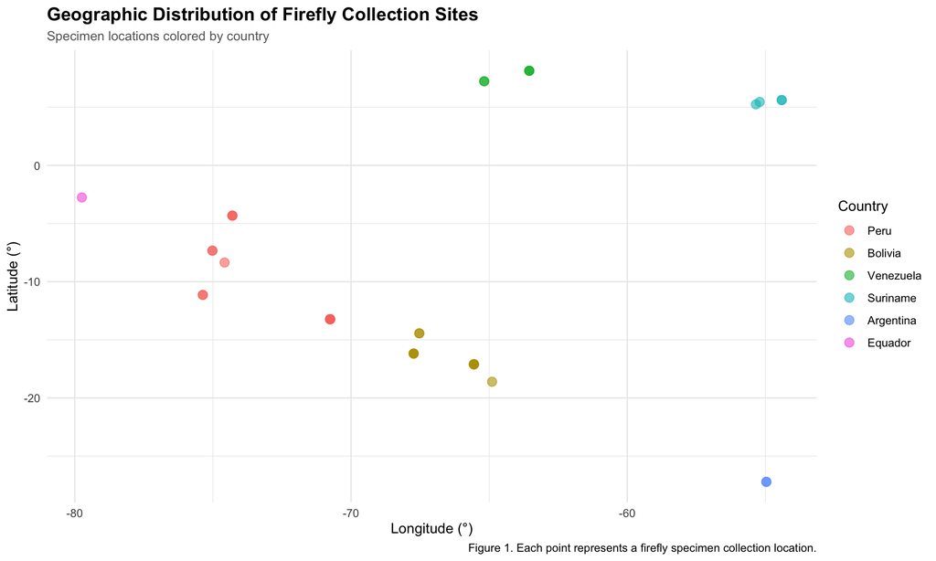

**Figure 1.** Geographic distribution shows most of collection efforts clustered in regions rather than spred out, with most specimens collected in Peru. The latitudinal range spans from tropical to temperate zones.

# Morphometric Patterns

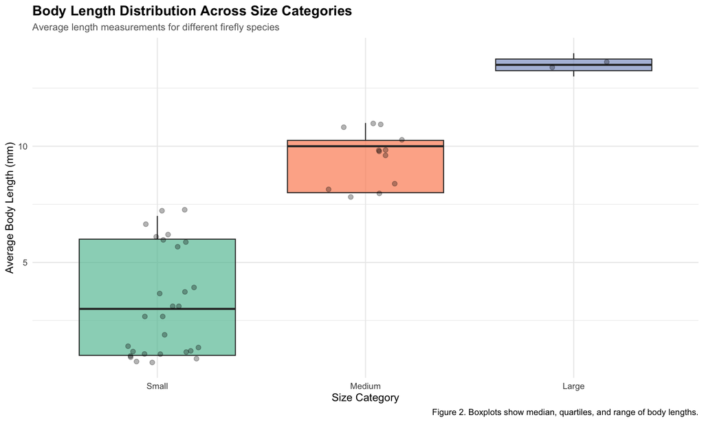

**Figure 2.** Body size is catagorized into the following: small species under 8mm, medium species between 8-12mm, and large species greater than 12mm in length.

# Key Findings and Future Directions

## Recommendations for Future Analysis

- **Biogeographic Analysis**: Investigate whether size patterns truly correlate with latitude or elevation.
- **Temporal Trends**: Examine whether collection locations have shifted over time, potentially reflecting habitat changes or bias by collectors
- **Species Distribution Modeling**: Use the occurrence data combined with environmental variables to model habitat suitability (ENM)
- **Morphological Evolution**: Analyze the relationship between body size and geographic distribution to test evolutionary hypotheses

## Data Quality Improvements

Future data collection should focus on:

- Expanded geographic coverage to fill sampling gaps and time gaps
- Integration with molecular data for phylogenetic context

*This report was generated using R and Quarto. All code is available in the accompanying GitHub repository.*